[figure not shown]

ME(w/o STI)-2

General Description

MECHANICAL

1. General Description

A: SPECIFICATION

Engine

Model 2.0 L

Cylinder arrangement

Horizontally opposed, liquid cooled, 4-cylinder,

4-stroke gasoline engine

Valve system mechanism

Chain driven, double overhead camshaft,

4-valve/cylinder

Bore × Stroke mm (in) 86.0 × 86.0 (3.39 × 3.39)

Displacement cm

3

(cu in) 1,998 (121.92)

Compression ratio 10.6

Compression pressure

(at 200 — 300 rpm)

kPa (kg/cm

2

, psi) Standard 1,350 — 1,750 (14 — 18, 196 — 254)

Number of piston rings

Compression ring: 2

Oil ring: 1

Intake valve timing

Open

Max. retard ATDC 26°

Min.

advance

BTDC 42°

Close

Max. retard ABDC 82°

Min.

advance

ABDC 14°

Exhaust valve timing

Open

Max. retard BBDC 11°

Min.

advance

BBDC 66°

Close

Max. retard ATDC 55°

Min.

advance

ATD C 0 °

Cam clearance mm (in)

Intake Standard 0.13

+0.02

–0.03

(0.0051

+0.0008

–0.0012

)

Exhaust Standard 0.22±0.02 (0.0087±0.0008)

Idle speed (For CVT model,

select lever in “P” or “N” range.

For MT model, gear shift lever in

neutral position.)

rpm

No load Standard 700±100

A/C ON Standard 700 — 865±50

Ignition order 1 → 3 → 2 → 4

Ignition timing BTDC/rpm Standard 10°±10°/700

[figure not shown]

ME(w/o STI)-3

General Description

MECHANICAL

NOTE:

OS: Oversize US: Undersize

Camshaft

Bending mm (in) Limit 0.020 (0.00079)

Cam

lobe

height

mm (in)

Intake

Valve drive section Standard 40.34 — 40.44 (1.588 — 1.592)

Fuel pump drive section Standard 41.95 — 42.05 (1.652 — 1.656)

Exhaust Standard 40.20 — 40.30 (1.583 — 1.587)

Cam base circle diameter mm (in) Standard 34.0 (1.339)

Journal outer diameter mm (in) Standard 25.946 — 25.963 (1.0215 — 1.0222)

Thrust clearance mm (in) Standard 0.068 — 0.116 (0.0027 — 0.0047)

Oil clearance mm (in) Standard 0.037 — 0.072 (0.0015 — 0.0028)

Cylinder

head

Warpage (mating surface with cylinder block) mm (in) Limit 0.020 (0.00079)

Grinding limit mm (in) To 98.4 (3.874)

Height mm (in) Standard 98.5 (3.878)

Valve &

valve guide

Valve overall length mm (in)

Intake 104.95 (4.132)

Exhaust 97.9 (3.854)

Valve head edge thickness mm (in)

Intake Standard 0.8 — 1.2 (0.031 — 0.047)

Exhaust Standard 1.0 — 1.4 (0.039 — 0.055)

Valve stem outer diameter mm (in)

Intake Standard 5.455 — 5.470 (0.2148 — 0.2154)

Exhaust Standard 5.445 — 5.460 (0.2144 — 0.2150)

Valve guide inner diameter mm (in) Standard 5.500 — 5.512 (0.2165 — 0.2170)

Clearance between valve and

valve guide

mm (in)

Intake Standard 0.030 — 0.057 (0.0012 — 0.0022)

Exhaust Standard 0.040 — 0.067 (0.0016 — 0.0026)

Valve guide protrusion amount mm (in) Standard 11.4 — 11.8 (0.449 — 0.465)

Valve &

valve shim

Valve stem end outer diameter mm (in)

Intake Standard 5.455 — 5.470 (0.2148 — 0.2154)

Exhaust Standard 5.445 — 5.460 (0.2144 — 0.2150)

Valve shim inner diameter mm (in) Standard 5.500 — 5.560 (0.2165 — 0.2189)

Clearance between valve and

valve shim

mm (in)

Intake Standard 0.030 — 0.105 (0.0012 — 0.0041)

Exhaust Standard 0.040 — 0.115 (0.0016 — 0.0045)

Valve seat

Seating width between valve

and valve seat

mm (in)

Intake Standard 0.8 — 1.6 (0.031 — 0.063)

Exhaust Standard 1.1 — 1.7 (0.043 — 0.067)

Seating angle between valve and valve seat 45°

Seating position between valve and valve seat Valve face center

Valve spring

Free length mm (in) Standard

CVT model: 41.68 (1.641)

MT model: 41.06 (1.617)

Tension/spring height N (kgf, lb)/mm (in)

Set Standard

182 — 210

(18.56 — 21.41, 40.92 — 47.22)/

33.0 (1.299)

Lift Standard

CVT model: 502 — 554

(51.19 — 56.49, 112.87 — 124.56)/

22.0 (0.866)

MT model: 552 — 610

(56.29 — 62.20, 124.11 — 137.15)/

22.0 (0.866)

Squareness Standard 2.5°, 1.8 mm (0.071 in) or less

[figure not shown]

ME(w/o STI)-4

General Description

MECHANICAL

Cylinder

block & pis-

ton

Cylinder block warpage

(Mating surface with cylinder head)

mm (in) Limit 0.025 (0.00098)

Grinding limit of cylinder block mm (in) To 204.9 (8.067)

Height of cylinder block mm (in) Standard 205.0 (8.071)

Inner diameter of cylinder liner mm (in)

Cylinder bore size

mark A

Standard 86.005 — 86.015 (3.3860 — 3.3864)

Cylinder bore size

mark B

Standard 85.995 — 86.005 (3.3856 — 3.3860)

Cylindricality of cylinder liner mm (in) Limit 0.030 (0.0012)

Out-of-roundness of cylinder liner mm (in) Limit 0.030 (0.0012)

Piston grade point mm (in) 40.0 (1.57)

Piston outer diameter mm (in)

Standard

Size

Grade A Standard 85.985 — 85.995 (3.3852 — 3.3856)

Grade B Standard 85.975 — 85.985 (3.3848 — 3.3852)

0.25 (0.0098) OS Standard 86.225 — 86.245 (3.3947 — 3.3955)

0.50 (0.0197) OS Standard 86.475 — 86.495 (3.4045 — 3.4053)

Clearance between cylinder liner and piston mm (in) Standard 0.010 — 0.030 (0.00039 — 0.00118)

Inner diameter of cylinder liner boring limit (diameter) mm (in) To 86.505 (3.4057)

Piston and

piston pin

Degree of fit

Piston pin must be fitted into posi-

tion with thumb at 20°C (68°F).

Clearance between piston and piston pin mm (in) Standard 0.004 — 0.008 (0.0002 — 0.0003)

Piston ring

Closed

gap

mm (in)

Compression ring

Top ring Standard 0.20 — 0.25 (0.0079 — 0.0098)

Second ring Standard 0.40 — 0.50 (0.0157 — 0.0197)

Oil ring

(Upper rail and lower rail)

Standard 0.10 — 0.35 (0.0039 — 0.0138)

Clearance between compres-

sion ring and piston

mm (in)

Top ring Standard 0.040 — 0.080 (0.0016 — 0.0031)

Second ring Standard 0.045 — 0.085 (0.0018 — 0.0033)

Connecting

rod and con-

necting rod

bearing

Bend or twist per 100 mm (3.94 in) in length mm (in) Limit 0.10 (0.0039)

Thrust clearance mm (in) Standard 0.070 — 0.330 (0.0028 — 0.0130)

Connecting rod bearing thick-

ness (at center)

mm (in)

Standard size Standard 1.492 — 1.508 (0.0587 — 0.0594)

0.03 (0.0012) US Standard 1.511 — 1.515 (0.0595 — 0.0596)

0.05 (0.0020) US Standard 1.521 — 1.525 (0.0599 — 0.0600)

0.25 (0.0098) US Standard 1.621 — 1.625 (0.0638 — 0.0640)

Oil clearance mm (in) Standard 0.025 — 0.055 (0.0010 — 0.0022)

Piston pin &

connecting

rod bushing

Clearance between piston pin and connecting rod

bushing

mm (in) Standard 0.004 — 0.026 (0.0002 — 0.0010)

[figure not shown]

ME(w/o STI)-5

General Description

MECHANICAL

Crankshaft

and crank-

shaft bear-

ing

Bending mm (in) Limit 0.035 (0.0014)

Crankshaft pin

Cylindricality mm (in) Limit 0.006 (0.0002)

Out-of-roundness mm (in) Limit 0.005 (0.0002)

Grinding limit (dia.) mm (in) To 49.726 (1.9577)

Crankshaft journal

Cylindricality mm (in) Limit 0.006 (0.0002)

Out-of-roundness mm (in) Limit 0.005 (0.0002)

Grinding limit (dia.) mm (in) To 67.735 (2.6667)

Crankshaft pin outer diameter mm (in)

Standard size Standard 49.976 — 50.000 (1.9676 — 1.9685)

0.03 (0.0012) US Standard 49.946 — 49.970 (1.9664 — 1.9673)

0.05 (0.0020) US Standard 49.926 — 49.950 (1.9656 — 1.9665)

0.25 (0.0098) US Standard 49.726 — 49.750 (1.9577 — 1.9587)

Crankshaft journal outer diame-

ter

mm (in)

Standard size Standard 67.985 — 68.009 (2.6766 — 2.6775)

0.03 (0.0012) US Standard 67.955 — 67.979 (2.6754 — 2.6763)

0.05 (0.0020) US Standard 67.935 — 67.959 (2.6746 — 2.6755)

0.25 (0.0098) US Standard 67.735 — 67.759 (2.6667 — 2.6677)

Crankshaft bearing

thickness (at center)

mm (in)

#1, #2,

#3, #4

Standard size Standard 2.495 — 2.513 (0.0982 — 0.0989)

0.03 (0.0012) US Standard 2.519 — 2.522 (0.0992 — 0.0993)

0.05 (0.0020) US Standard 2.529 — 2.532 (0.0996 — 0.0997)

0.25 (0.0098) US Standard 2.629 — 2.632 (0.1035 — 0.1036)

#5

Standard size Standard 2.493 — 2.511 (0.0981 — 0.0989)

0.03 (0.0012) US Standard 2.517 — 2.520 (0.0991 — 0.0992)

0.05 (0.0020) US Standard 2.527 — 2.530 (0.0995 — 0.0996)

0.25 (0.0098) US Standard 2.627 — 2.630 (0.1034 — 0.1035)

Thrust clearance mm (in) Standard 0.130 — 0.308 (0.00512 — 0.01213)

Oil clearance mm (in) Standard 0.013 — 0.031 (0.00051 — 0.00122)

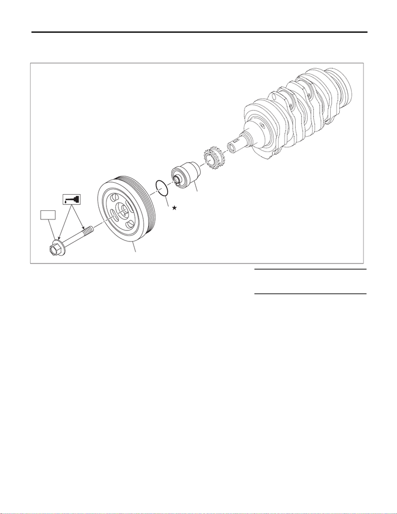

ME(w/o STI)-6

General Description

MECHANICAL

B: COMPONENT

1. CRANK PULLEY

(1) Crank pulley (3) Crank pulley boss Tightening torque: N·m (kgf-m, ft-lb)

(2) O-ring T: <Ref. to ME(w/o STI)-87,

INSTALLATION, Crank Pulley.>

ME-06496

T

(2)

(1)

(3)

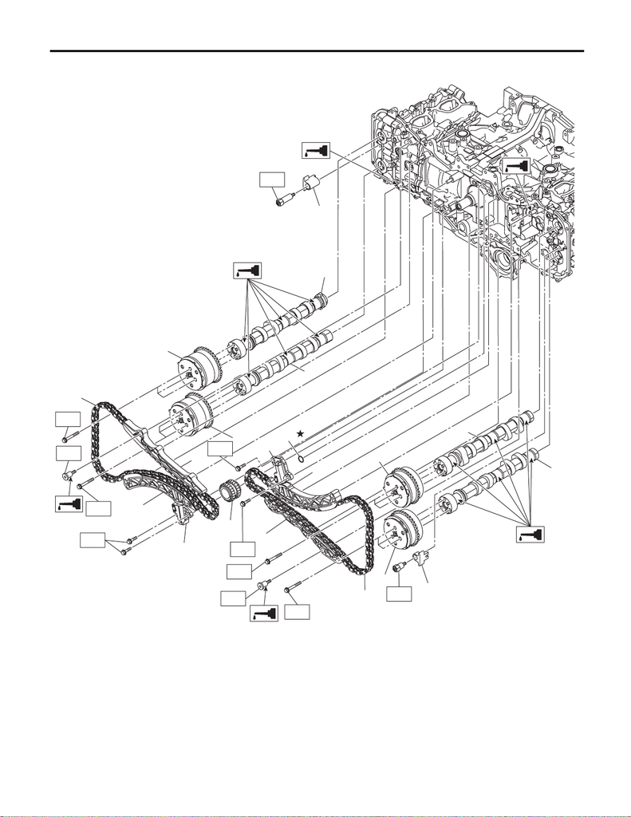

ME(w/o STI)-7

General Description

MECHANICAL

2. TIMING CHAIN & CAMSHAFT

ME-07893

(5)

(3)

(1)

(4)

(6)

(7)

(9)

(8)

(10)

(11)

(12)

(13)

(15)

T1

T2

T2

T1

T1

T2

T1

T2

T1

(14)

(2)

T1

T1

(17)

(16)

(7)

(5)

(18)

[figure not shown]

ME(w/o STI)-8

General Description

MECHANICAL

(1) Intake camshaft RH (9) Crank sprocket (17) Chain guide C

(2) Exhaust camshaft RH (10) O-ring (18) Chain guide D

(3) Intake cam sprocket RH (11) Chain tensioner LH

(4) Exhaust cam sprocket RH (12) Intake cam sprocket LH Tightening torque: N·m (kgf-m, ft-lb)

(5) Timing chain (13) Exhaust cam sprocket LH T1: 6.4 (0.7, 4.7)

(6) Chain guide A (14) Intake camshaft LH T2: 18 (1.8, 13.3)

(7) Chain tension lever (15) Exhaust camshaft LH

(8) Chain tensioner RH (16) Chain guide B

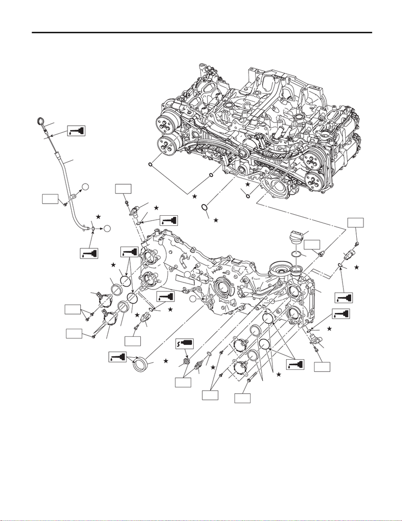

ME(w/o STI)-9

General Description

MECHANICAL

3. CHAIN COVER

ME-07894

(18)

T

2

T1

T1

T1

T1

T

3

T1

A

A

B

B

(13)

(14)

(15)

(16)

(17)

(17)

(5)

T1

(4)

(3)

(9)

(10)

(11)

(12)

(6)

(7)

(8)

(3)

(4)

T

1

T1

(4)

(8)

T1

(4)

(8)

(3)

(7)

(6)

(3)

(6)

(6)

(7)

(1)

(2)

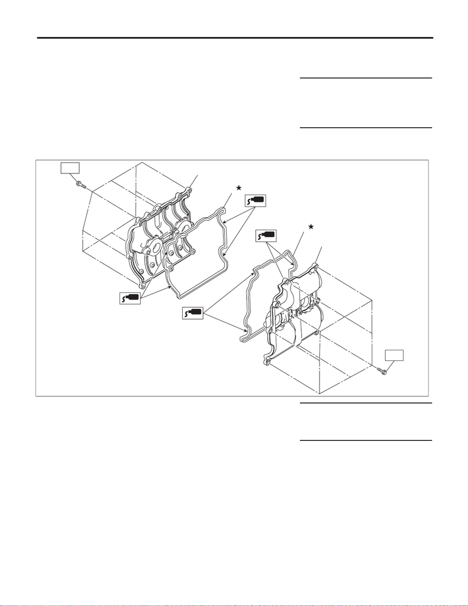

ME(w/o STI)-10

General Description

MECHANICAL

4. ROCKER COVER

(1) Oil filler cap (9) Engine oil temperature sensor (17) O-ring

(2) Gasket (10) Gasket (18) O-ring

(3) Camshaft position sensor (11) Oil pressure switch

(4) O-ring (12) Front oil seal Tightening torque: N·m (kgf-m, ft-lb)

(5) Chain cover (13) Oil level gauge T1: 6.4 (0.7, 4.7)

(6) Oil control solenoid (14) O-ring T2: 18 (1.8, 13.3)

(7) Back-up ring (15) Oil level gauge guide T3: <Ref. to ME(w/o STI)-101,

INSTALLATION, Chain Cover.>

(8) O-ring (16) O-ring

(1) Rocker cover RH (3) Rocker cover gasket LH Tightening torque: N·m (kgf-m, ft-lb)

(2) Rocker cover gasket RH (4) Rocker cover LH T: <Ref. to ME(w/o STI)-161,

INSTALLATION, Rocker

Cover.>

ME-06624

(3)

(4)

T

(1)

T

(2)

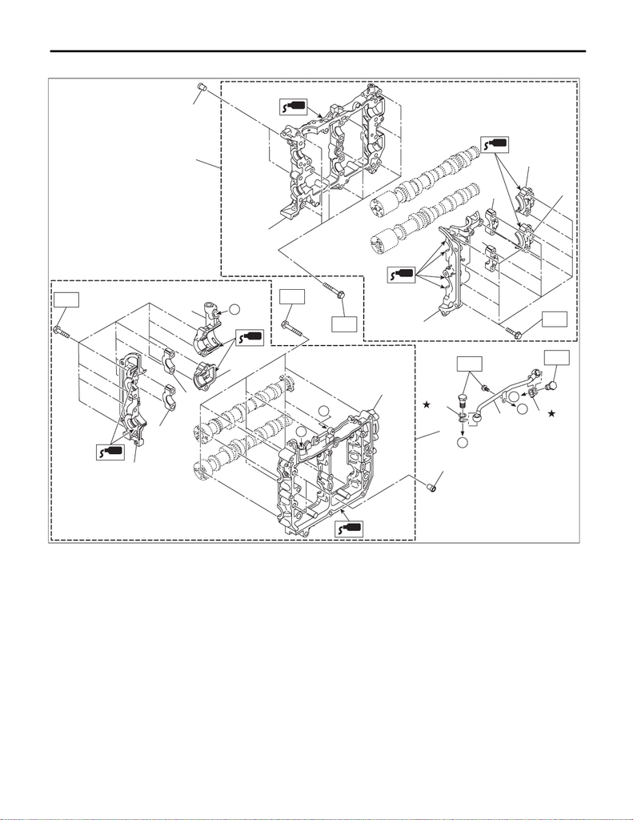

ME(w/o STI)-11

General Description

MECHANICAL

5. CAM CARRIER

ME-07130

T2

(12)

(14)

(15)

(13)

(16)

T3

(2)

T3

(4)

(3)

(5)

(6)

(7)

T2

(8)

(1)

(8)

(17)

A

B

C

A

B

C

T1

T1

(10)

(10)

(11)

(9)

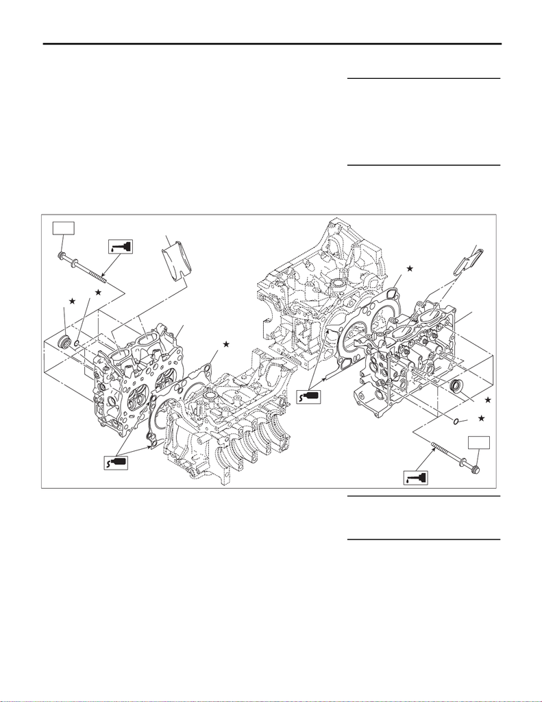

ME(w/o STI)-12

General Description

MECHANICAL

6. CYLINDER HEAD

(1) Cam carrier ASSY RH (9) Oil pipe (17) Exhaust rear camshaft cap LH

(2) Front camshaft cap RH (10) Gasket

(3) Intake center camshaft cap RH (11) Cam carrier ASSY LH Tightening torque: N·m (kgf-m, ft-lb)

(4) Exhaust center camshaft cap RH (12) Cam carrier LH T1: <Ref. to ME(w/o STI)-204, CAM

CARRIER RH, ASSEMBLY, Cam

Carrier.>

(5) Intake rear camshaft cap RH (13) Front camshaft cap LH T2: <Ref. to ME(w/o STI)-204,

ASSEMBLY, Cam Carrier.>

(6) Exhaust rear camshaft cap RH (14) Intake center camshaft cap LH T3: <Ref. to ME(w/o STI)-180,

INSTALLATION, Cam Carrier.>

(7) Cam carrier RH (15) Exhaust center camshaft cap LH

(8) Filter (16) Intake rear camshaft cap LH

(1) Spark plug pipe gasket (5) Cylinder head gasket RH Tightening torque: N·m (kgf-m, ft-lb)

(2) O-ring (6) Cylinder head gasket LH T: <Ref. to ME(w/o STI)-218,

INSTALLATION, Cylinder

Head.>

(3) Cylinder head plate (7) Cylinder head LH

(4) Cylinder head RH

T

(1)

(2)

(7)

(3)

(6)

ME-06626

T

(1)

(2)

(4)

(5)

(3)

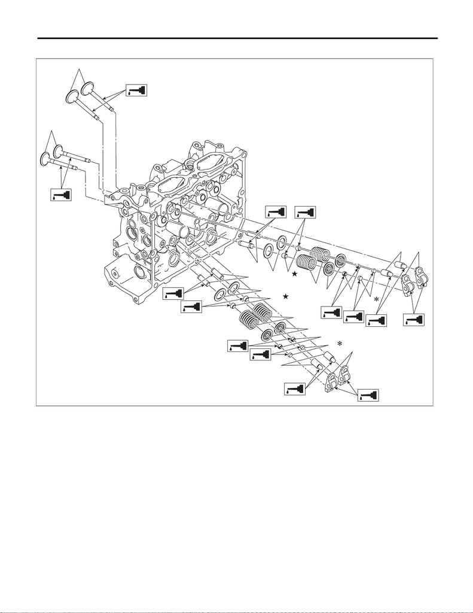

ME(w/o STI)-13

General Description

MECHANICAL

7. VALVE ASSEMBLY

(1) Exhaust valve (6) Valve spring (11) Roller rocker arm

(2) Intake valve (7) Valve spring retainer (12) Exhaust valve guide

(3) Intake valve guide (8) Valve collet (13) Exhaust valve oil seal

(4) Valve spring seat (9) Valve shim

(5) Intake valve oil seal (10) Roller rocker arm pivot

ME-06627

(1)

(4)

(5)

(6)

(8)

(9)

(10)

(11)

(7)

(11)

(12)

(4)

(13)

(6)

(7)

(8)

(9)

(2)

(10)

(3)

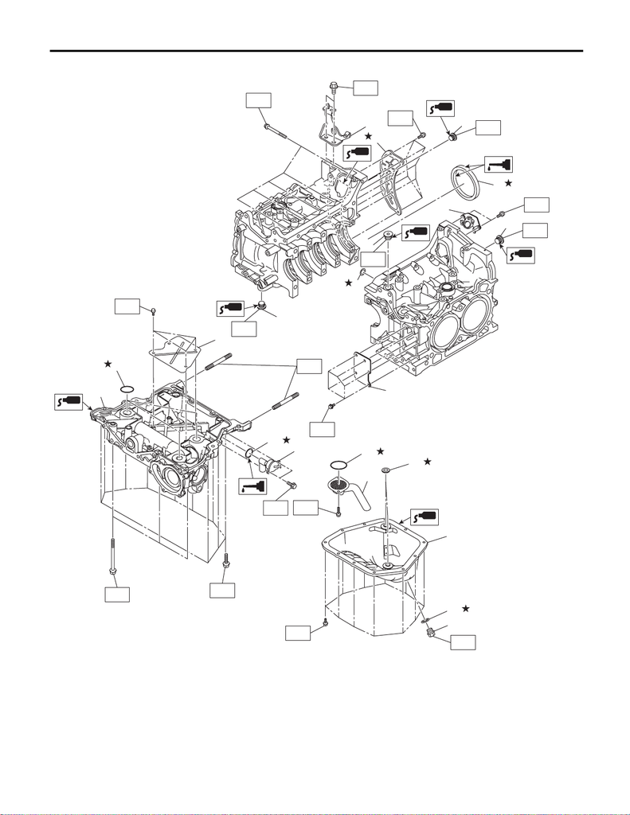

ME(w/o STI)-14

General Description

MECHANICAL

8. CYLINDER BLOCK 1

ME-07895

T4

T5

T8

T1

T7

T6

T6

T1

T6

T3

T6

T6

(9)

(11)

(4)

(14)

(15)

(16)

(18)

(17)

(19)

T7

T1

T2

T1

(8)

(5)

(4)

(4)

(7)

(6)

(3)

(2)

(1)

(10)

T1

(13)

(12)

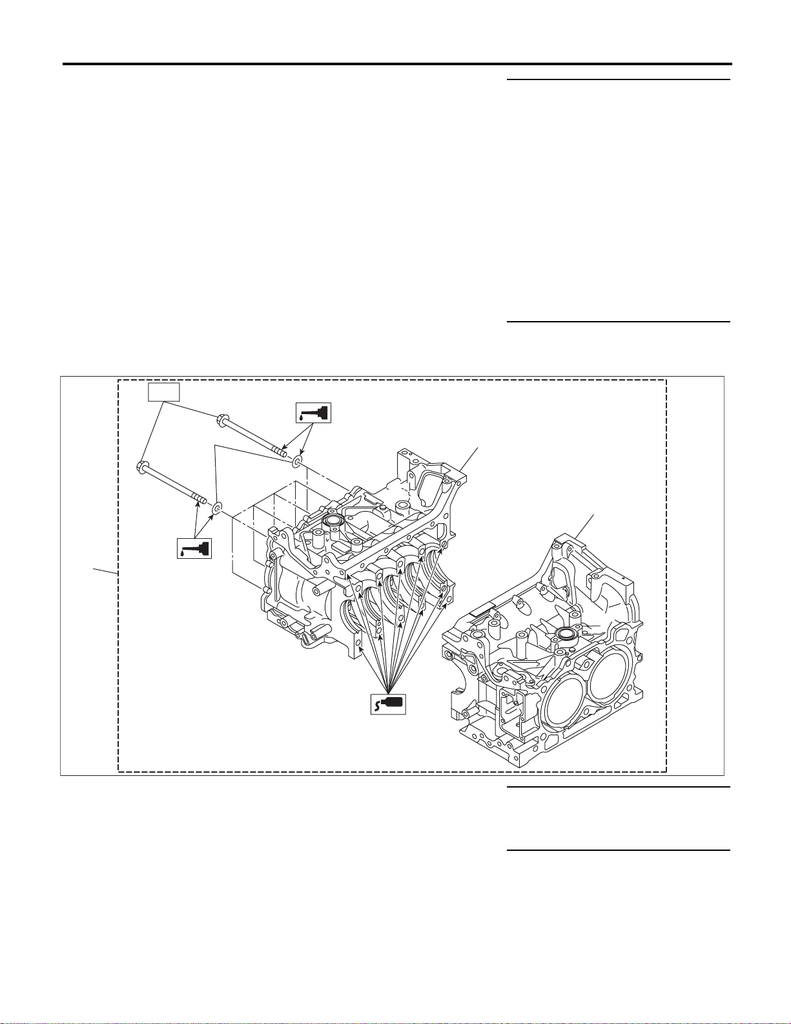

ME(w/o STI)-15

General Description

MECHANICAL

9. CYLINDER BLOCK 2

(1) Engine rear hanger (11) Baffle plate Tightening torque: N·m (kgf-m, ft-lb)

(2) Oil separator cover (12) O-ring T1: 6.4 (0.7, 4.7)

(3) Cylinder block plug (13) Oil level switch T2: 10 (1.0, 7.4)

(4) Main gallery plug (14) O-ring T3: 21 (2.1, 15.5)

(5) O-ring (15) Oil strainer T4: 25 (2.5, 18.4)

(6) Rear oil seal (16) Oil pan seal ring T5: 41.7 (4.3, 30.8)

(7) Crankshaft position sensor holder (17) Oil pan T6: <Ref. to ME(w/o STI)-305, CYL-

INDER BLOCK, ASSEMBLY,

Cylinder Block.>

(8) Cylinder block plate (18) Drain plug gasket T7: <Ref. to ME(w/o STI)-272,

INSTALLATION, Cylinder

Block.>

(9) O-ring (19) Drain plug T8: <Ref. to LU(w/o STI)-21, OIL

PAN AND STRAINER, INSTAL-

LATION, Oil Pan and Strainer.>

(10) Oil pan upper

(1) Cylinder block ASSY (3) Cylinder block RH Tightening torque: N·m (kgf-m, ft-lb)

(2) Washer (4) Cylinder block LH T: <Ref. to ME(w/o STI)-272,

INSTALLATION, Cylinder

Block.>

ME-06447

(1)

(2)

T

(3)

(4)

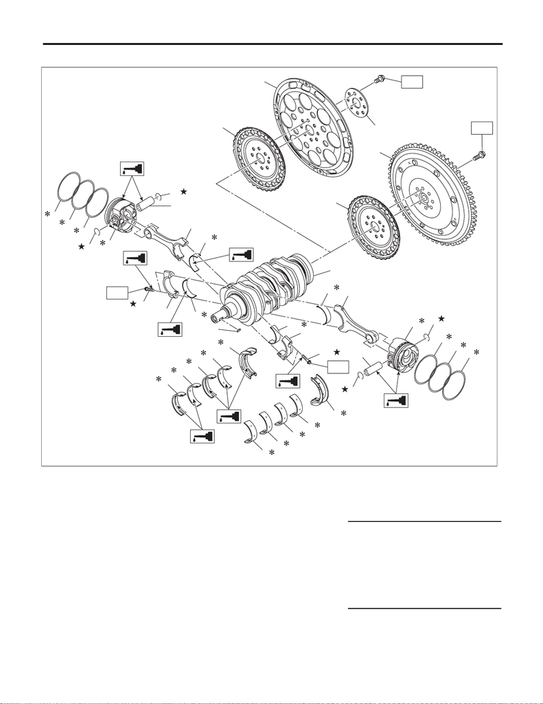

ME(w/o STI)-16

General Description

MECHANICAL

10.CRANKSHAFT AND PISTON

(1) Reinforcement drive plate (CVT

model)

(10) Piston pin (19) Crankshaft bearing #2, #4

(2) Drive plate (CVT model) (11) Connecting rod cap bolt (20) Crankshaft bearing #5

(3) Crankshaft position sensor plate (12) Connecting rod

(4) Flywheel (MT model) (13) Connecting rod bearing Tightening torque: N·m (kgf-m, ft-lb)

(5) Top ring (14) Connecting rod cap T1: <Ref. to ME(w/o STI)-272,

INSTALLATION, Cylinder

Block.>

(6) Second ring (15) Piston LH T2: <Ref. to CVT(TR690)-138,

INSTALLATION, Drive Plate.>

(7) Oil ring (16) Crankshaft T3: <Ref. to CL-15, INSTALLATION,

Flywheel.>

(8) Piston RH (17) Woodruff key

(9) Circlip (18) Crankshaft bearing #1, #3

(1)

(2)

(3)

T2

ME-07896

(5)

(6)

(7)

(5)

(6)

(7)

(8)

(11)

(12)

(13)

(13)

(14)

(16)

(17)

(13)

(14)

(11)

(13)

(12)

(18)

(19)

(18)

(19)

(20)

T1

T1

(9)

(9)

(9)

(9)

(19)

(20)

(18)

(19)

(18)

(4)

(3)

T3

(10)

(15)

(10)

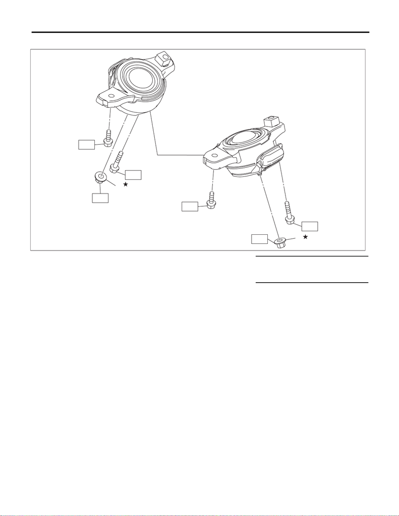

ME(w/o STI)-17

General Description

MECHANICAL

11.ENGINE MOUNTING

C: CAUTION

• Prior to starting work, pay special attention to the following:

1. Always wear work clothes, a work cap, and protective shoes. Additionally, wear a helmet, protective

goggles, etc. if necessary.

2. Protect the vehicle using a seat cover, fender cover, etc.

3. Prepare the service tools, clean cloth, containers to catch grease and oil, etc.

• Vehicle components are extremely hot immediately after driving. Be wary of receiving burns from heated

parts.

• When performing a repair, identify the cause of trouble and avoid unnecessary removal, disassembly and

replacement.

• Before disconnecting connectors of sensors or units, be sure to disconnect the ground cable from battery.

• Always use the jack-up point when the shop jacks or rigid racks are used to support the vehicle.

• Remove or install the engine in an area where chain hoists, lifting devices, etc. are available for ready use.

When lifting up the vehicle, make sure to support the vehicle at the jack-up points.

• Be careful not to let any oil or grease contact the clutch disc or flywheel.

• Remove contamination including dirt and corrosion before removal, installation, disassembly or assembly.

• Keep the removed parts in order and protect them from dust and dirt.

• All removed parts, if to be reused, should be reinstalled in the original positions with attention to the correct

directions, etc.

• Rotating parts and sliding parts such as piston, bearing and gear should be coated with oil when being as-

sembled.

• Bolts, nuts and washers should be replaced with new parts as required.

• Be sure to tighten the fasteners including bolts and nuts to the specified torque.

(1) Front cushion rubber (2) Nut Tightening torque: N·m (kgf-m, ft-lb)

T1: 35 (3.6, 25.8)

T2: 60 (6.1, 44.3)

ME-08026

(1)

T2

T1

T2

T1

T1

T1

(2)

(2)

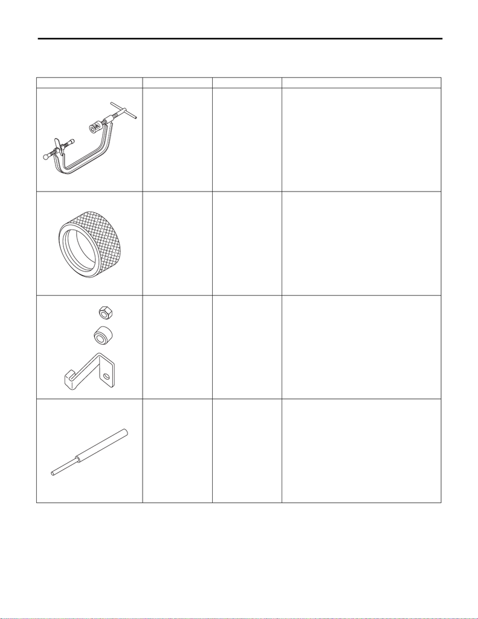

ME(w/o STI)-18

General Description

MECHANICAL

D: PREPARATION TOOL

1. SPECIAL TOOL

ILLUSTRATION TOOL NUMBER DESCRIPTION REMARKS

0920287002000 REMOVER AND

REPLACER

Used for removing and installing valve spring.

398437700 OIL SEAL

INSTALLER

Used for installing the front oil seal of engine.

498277200 STOPPER SET Used for preventing the torque converter from fall-

ing when removing and installing the engine.

(CVT model)

499765700 VALVE GUIDE

REMOVER AND

INSTALLER

Used for removing and installing valve guide.

ST0920287002000

ST-398437700

ST-498277200

ST-499765700

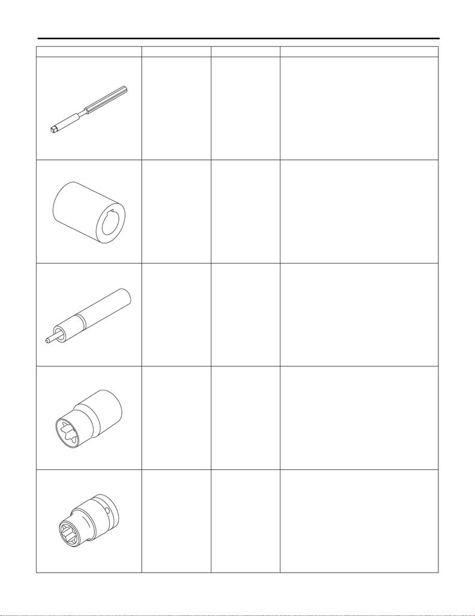

ME(w/o STI)-19

General Description

MECHANICAL

499765900 VALVE GUIDE

REAMER

Used for reaming valve guides.

18252AA000 CRANKSHAFT

SOCKET

Used for rotating crankshaft.

18261AA010 VALVE OIL SEAL

GUIDE

Used for press-fitting of intake valve oil seals and

exhaust valve oil seals.

18270AA020 SOCKET Used for removing and installing connecting rod.

18270KA010 SOCKET Used for installing and removing intake cam

sprocket and exhaust cam sprocket.

ILLUSTRATION TOOL NUMBER DESCRIPTION REMARKS

ST-499765900

ST18252AA000

ST18261AA010

ST18270AA020

ST18270KA010

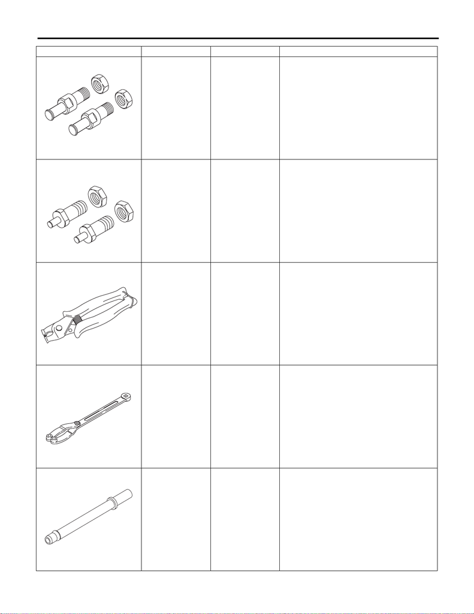

ME(w/o STI)-20

General Description

MECHANICAL

18334AA000 PULLEY WRENCH

PIN SET

• Used for removing and installing the crank pul-

ley.

• Used together with PULLEY WRENCH

(18355AA000).

18334AA020 PULLEY WRENCH

PIN SET

• Used for removing and installing intake cam

sprocket and exhaust cam sprocket.

• Used together with PULLEY WRENCH

(18355AA000).

18353AA000 CLAMP PLIERS • Used for removing and installing the PCV hose

assembly.

• This tool is made by the French company CAIL-

LAU. (code) 54.0.000.205

To make it easier to obtain, it has been provided

with a tool number.

18355AA000 PULLEY WRENCH • Used for removing and installing the crank pul-

ley.

• Used for removing and installing intake cam

sprocket and exhaust cam sprocket.

• Used together with PULLEY WRENCH PIN

SET (18334AA000) or PULLEY WRENCH PIN

SET (18334AA020).

18471AA000 FUEL PIPE

ADAPTER

Used for inspecting the fuel pressure.

ILLUSTRATION TOOL NUMBER DESCRIPTION REMARKS

ST18334AA000

ST18334AA020

ST18353AA000

ST18355AA000

ST18471AA000

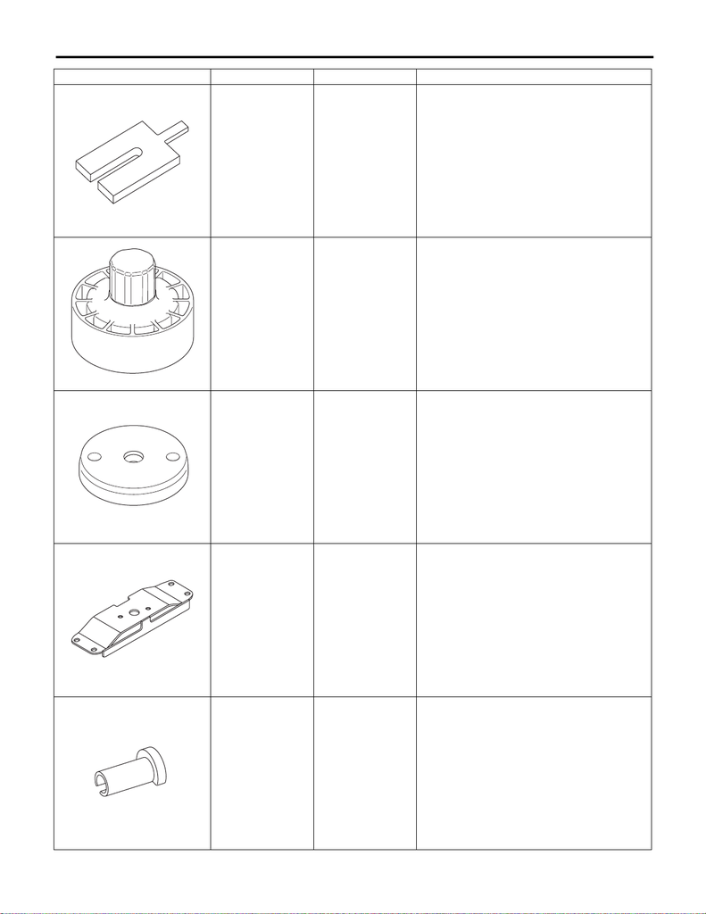

ME(w/o STI)-21

General Description

MECHANICAL

18632AA030

(Newly adopted

tool)

STAND ASSY Used for removing and installing rocker cover LH.

18657AA030 OIL SEAL

INSTALLER

• Used for installing the rear oil seal of engine.

• Used together with OIL SEAL GUIDE

(18671AA020).

18671AA020 OIL SEAL GUIDE • Used for installing the rear oil seal of engine.

• Used together with OIL SEAL INSTALLER

(18657AA030).

41099YC001

(Newly adopted

tool)

ST REAR MOUNT Used for removing and installing engine. (CVT

model)

42099AE000 QUICK CONNEC-

TOR RELEASE

Used for removing FUEL HOSE (42075AG690).

NOTE:

FUEL HOSE (42075AG690) is used for checking

the fuel pressure.

ILLUSTRATION TOOL NUMBER DESCRIPTION REMARKS

ST18632AA030

ST18657AA030

ST18671AA020

ST41099YC001

ST42099AE000

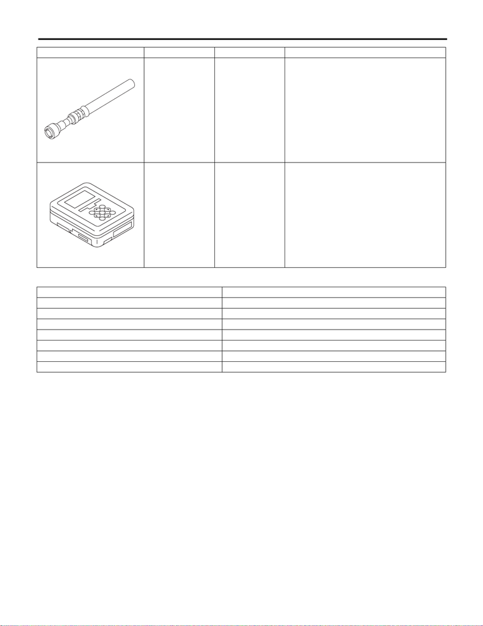

ME(w/o STI)-22

General Description

MECHANICAL

2. GENERAL TOOL

42075AG690 FUEL HOSE Used for inspecting the fuel pressure.

NOTE:

This is the SUBARU genuine part.

1B022XU0 SUBARU SELECT

MONITOR III KIT

Used for various inspections.

TOOL NAME REMARKS

Compression gauge Used for measuring compression.

Vacuum gauge Used for measuring intake manifold vacuum.

Oil pressure gauge Used for measuring engine oil pressure.

Fuel pressure gauge Used for measuring fuel pressure.

Piston ring compressor Used for installing the piston into the cylinder block.

Thickness gauge Used for various inspections.

Angle gauge Used for angle tightening.

ILLUSTRATION TOOL NUMBER DESCRIPTION REMARKS

ST42075AG690

ST1B022XU0